# Midterm Project

Daeshik Park

I will investigate the data temp_carbon obtained from the data package dslabs. The data temp_carbon has 5 columns: year, temp_anomaly, land_anomaly, ocean_anomaly, and carbon_emissions. The anomalies are deviations from the baseline the 20th century average. According to NOAA, the 20th century average temperature of the global land and ocean surface is 14.8°C (58.6°F) and the 20th century average temperature of the global land-only surface is 11.1°C (52.0°F). Temperature anomalies are in degrees Celsius and carbon emissions are in millions of metric tons.

Read the data temp_carbon.

```r
library("dslabs")
#data(package = "dslabs")
data("temp_carbon")
glimpse(temp_carbon)
```

```
## Rows: 268
## Columns: 5
## $ year             <dbl> 1880, 1881, 1882, 1883, 1884, 1885, 1886, 1887, 18...
## $ temp_anomaly     <dbl> -0.11, -0.08, -0.10, -0.18, -0.26, -0.25, -0.24, -...
## $ land_anomaly     <dbl> -0.48, -0.40, -0.48, -0.66, -0.69, -0.56, -0.51, -...
## $ ocean_anomaly    <dbl> -0.01, 0.01, 0.00, -0.04, -0.14, -0.17, -0.17, -0....
## $ carbon_emissions <dbl> 236, 243, 256, 272, 275, 277, 281, 295, 327, 327, ...
```

```r
summary(temp_carbon)
```

```
##       year       temp_anomaly     land_anomaly      ocean_anomaly
##  Min.   :1751   Min.   :-0.450   Min.   :-0.69000   Min.   :-0.46000
##  1st Qu.:1818   1st Qu.:-0.180   1st Qu.:-0.31500   1st Qu.:-0.17000
##  Median :1884   Median :-0.030   Median :-0.05000   Median :-0.01000
##  Mean   :1884   Mean   : 0.060   Mean   : 0.07086   Mean   : 0.05273
##  3rd Qu.:1951   3rd Qu.: 0.275   3rd Qu.: 0.30500   3rd Qu.: 0.25500
##  Max.   :2018   Max.   : 0.980   Max.   : 1.50000   Max.   : 0.79000
##                 NA's   :129      NA's   :129        NA's   :129
##  carbon_emissions
##  Min.   :   3.00
##  1st Qu.:  13.75
##  Median : 264.00
##  Mean   :1522.98
##  3rd Qu.:1431.50
##  Max.   :9855.00
##  NA's   :4
```

After looking at the data, there are no data values for anomalies from the years 1751 ~ 1879. Remove those years from the data.

```r
temp_carbon_1880 <- temp_carbon %>% filter(year >= 1880)
summary(temp_carbon_1880)
```

```
##       year       temp_anomaly     land_anomaly      ocean_anomaly
##  Min.   :1880   Min.   :-0.450   Min.   :-0.69000   Min.   :-0.46000
##  1st Qu.:1914   1st Qu.:-0.180   1st Qu.:-0.31500   1st Qu.:-0.17000
##  Median :1949   Median :-0.030   Median :-0.05000   Median :-0.01000
##  Mean   :1949   Mean   : 0.060   Mean   : 0.07086   Mean   : 0.05273
##  3rd Qu.:1984   3rd Qu.: 0.275   3rd Qu.: 0.30500   3rd Qu.: 0.25500
##  Max.   :2018   Max.   : 0.980   Max.   : 1.50000   Max.   : 0.79000
##
##  carbon_emissions
##  Min.   : 236
##  1st Qu.: 837
##  Median :1392
##  Mean   :2942
##  3rd Qu.:5116
##  Max.   :9855
##  NA's   :4
```

### Comparing Anomalies

Visualize the 3 anomaly variables in a plot to compare using highcharts.

```r
highchart() %>%
  hc_add_series(data = temp_carbon_1880$temp_anomaly,
                type = "column",
                name = "Global Temp Anomaly",
                color = "gray") %>% # bars for temp_anomaly
  hc_add_series(data = temp_carbon_1880$land_anomaly,
                type = "line",
                name = "Land Temp Anomaly",
                color = "green") %>% # lines for land_anomaly
  hc_add_series(data = temp_carbon_1880$ocean_anomaly,
                type = "line",
                name = "Ocean Temp Anomaly",
                color = "blue") %>% # lines for ocean_anomaly
  hc_title(text = "<b> Annual Temperature Anomalies </b>",
           align = "center") %>%
  hc_subtitle(text = "Baseline: 20th Century Mean Temperatures",
              align = "center") %>%
  hc_xAxis(title = list(text = "<b> Year </b>"),
           categories = temp_carbon_1880$year,
           tickInterval = 10) %>%
  hc_yAxis(title = list(text = "<b> Temperature Anomaly (degrees Celsius) </b>")) %>%
  hc_legend(align = "right", verticalAlign = "top") %>%
  hc_tooltip(shared = TRUE)
```

[interactive chart not shown]

**Summary:** During the world war II, there are positive deviations because they made extreme number of weapons of mass destruction. Since 1975, anomalies are positive and in an increasing trend. Industries were developed rapidly, and land anomalies became the main factor of global temperature anomalies.

### Animating the Variables temp_anomaly and carbon_emissions

Convert the variable year as an integer class and investigate covariate relation between the Variables temp_anomaly and carbon_emissions.

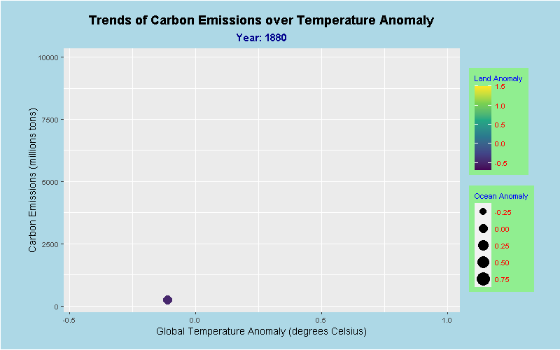

```r
temp_carbon_1880$year <- as.integer(temp_carbon_1880$year)

# static plot
gg1 <- ggplot(temp_carbon_1880, aes(temp_anomaly, carbon_emissions)) +
  geom_point(aes(color = land_anomaly, size = ocean_anomaly)) +
  labs(title = "Trends of Carbon Emissions over Temperature Anomaly",
       x = "Global Temperature Anomaly (degrees Celsius)",
       y = "Carbon Emissions (millions tons)",
       color = "Land Anomaly",
       size = "Ocean Anomaly") +
  scale_color_viridis_c()

# transition of states
gg2 <- gg1 +
  transition_time(year) +
  labs(subtitle = "Year: {frame_time}") +
  shadow_mark(color = "black", alpha = 1, size = 0.5)

# changing themes
gg3 <- gg2 +
  theme(plot.title = element_text(size = 13, face = "bold", hjust = 0.5),
        plot.subtitle = element_text(size = 11, face = "bold",
                                     color = "darkblue", hjust = 0.5),
        plot.background = element_rect("lightblue"),
        plot.margin = unit(c(0.5,1,0.5,1), "cm"),
        axis.text.x = element_text(size = 7),
        axis.text.y = element_text(size = 7),
        axis.title.x = element_text(size = 10),
        axis.title.y = element_text(size = 10),
        legend.title = element_text(color = "blue", size = 8),
        legend.text = element_text(color = "red", size = 7),
        legend.background = element_rect("lightgreen"))

animate(gg3, fps=3.5) # transition speed
```

**Summary:** Until mid-1940s, global temperature anomalies are negative, and the amounts of carbon emissions are stayed below. Since then, the amounts of carbon emissions keep increasing and most of the global temperature anomalies are positive. During the last 20 years (the 21st century), it looks to me that there are record highs in the two variables almost every year. So, I may project that we will have record highs in the two variables this year (but, there is a counter-factor, COVID-19). Overall, it seems that there is a positive correlation between the variables temp_anomaly and carbon_emissions.

### A visualization about the data from YouTube

To view the video, click “Open in Browser” on the top-left and then click the image.

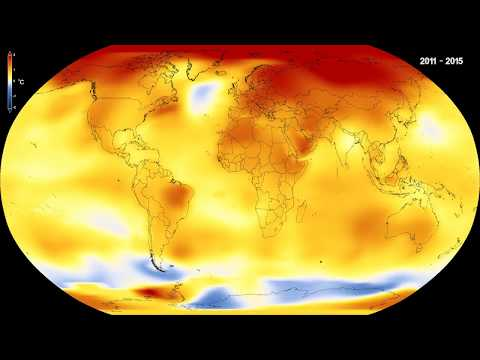